# Linear Regression in R

# Feature interpretation

## The interpretation of a weight in the linear regression model depends on the type of the corresponding feature

## Numerical feature

Increasing the numerical feature by one unit changes the estimated outcome by its weight, e.g. the size of a house.

## Binary feature

A feature that takes one of two possible values for each instance. Changing the feature from the reference category to the other category changes the estimated outcome by the feature’s weight, e.g. house with a garden encoded with 1, no garden encoded with 0.

## Categorical feature

A feature with a fixed number of possible values. The interpretation for each category is then the same as the interpretation for binary features, e.g. the floor type with possible categories “carpet”, “laminate” and “parquet”.

## The importance of a feature in a linear regression model can be measured by the absolute value of its t-statistic

## We can find the t-statistic by applying `summary()` function on `model` object

```r
summary(model)
```

```
##
## Call:
## lm(formula = SalePrice ~ GrLivArea + YearBuilt, data = ames_train)
##
## Residuals:
##     Min      1Q  Median      3Q     Max
## -456769  -26440   -2910   18008  280376
##
## Coefficients:
##               Estimate Std. Error t value Pr(>|t|)
## (Intercept) -2.008e+06  9.826e+04  -20.43   <2e-16 ***
## GrLivArea    9.625e+01  2.863e+00   33.63   <2e-16 ***
## YearBuilt    1.037e+03  5.017e+01   20.66   <2e-16 ***
## ---
## Signif. codes:  0 '***' 0.001 '**' 0.01 '*' 0.05 '.' 0.1 ' ' 1
##
## Residual standard error: 49090 on 1021 degrees of freedom
## Multiple R-squared:  0.6434, Adjusted R-squared:  0.6427
## F-statistic:   921 on 2 and 1021 DF,  p-value: < 2.2e-16
```

## Or calculating by ourselves

```r
tstats <- abs(model$coefficients / sqrt(diag(vcov(model))))
sort(tstats, decreasing = TRUE)
```

```
##   GrLivArea   YearBuilt (Intercept)
##    33.62551    20.66268    20.43371
```

## When does feature importance matter?

```r
is_complete <- c()
for (col_name in colnames(ames)) {
  if (sum(is.na(ames[, col_name])) > 0) {
    is_complete <- c(is_complete,  FALSE)
  } else  {
    is_complete <- c(is_complete,  TRUE)
  }
}
ames_complete <- ames[, is_complete]
```

## Building model with `ames_complete`

```r
model <- lm(SalePrice ~ ., data = ames_complete)
vi(model)
```

```
## # A tibble: 186 x 3
##    Variable        Importance Sign
##    <chr>                <dbl> <chr>
##  1 RoofMatlWdShngl      21.3  POS
##  2 RoofMatlCompShg      19.7  POS
##  3 RoofMatlTar&Grv      17.3  POS
##  4 RoofMatlWdShake      17.2  POS
##  5 RoofMatlRoll         15.7  POS
##  6 RoofMatlMembran      15.5  POS
##  7 RoofMatlMetal        14.8  POS
##  8 X2ndFlrSF            13.4  POS
##  9 X1stFlrSF            10.4  POS
## 10 BsmtFinSF1            8.42 POS
## # … with 176 more rows
```

## Negative t values are filled with red

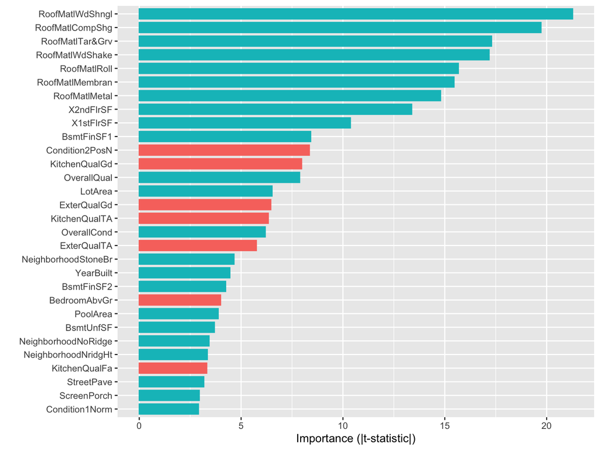

```r
vip(model, num_features = 30)
```